DS 6030 | Fall 2024 | University of Virginia

# Homework #2: Resampling

Author

**SOLUTIONS**

Published

Fall 2024

**Warning**

These solutions are only for the private use of the students of DS 6030 Fall 2024. Sharing of the solutions, posting on the internet, selling to a company, or possession by anyone outside of the class constitutes a violation of the honor policy.

# Required R packages and Directories

```r
data_dir = 'https://mdporter.github.io/teaching/data/' # data directory
library(tidymodels)# for optional tidymodels solutions
library(tidyverse) # functions for data manipulation
```

# Problem 1: Bootstrapping

Bootstrap resampling can be used to quantify the uncertainty in a fitted curve.

## a. Data Generating Process

Create a set of functions to generate data from the following distributions:
$$\begin{align*}
X &\sim \mathcal{U}(0, 2) \qquad \text{Uniform between $0$ and $2$}\\
Y &= 1 + 2x + 5\sin(5x) + \epsilon \\
\epsilon &\sim \mathcal{N}(0,\, \sigma=2.5)
\end{align*}$$

**Solution**

```r
#-- Simulation functions
sim_x <- function(n) runif(n, 0, 2)     # U[0,2]
f <- function(x) 1 + 2*x + 5*sin(5*x)   # true mean function
sim_y <- function(x){                   # generate Y|X from N{f(x),sd}
  n = length(x)
  f(x) + rnorm(n, sd=2.5)
}
```

## b. Simulate data

Simulate $n=100$ realizations from these distributions. Produce a scatterplot and draw the true regression line $f(x) = E[Y \mid X=x]$. Use `set.seed(211)` prior to generating the data.

**Solution**

```r
#-- Generate Data
n = 100                                 # number of observations
set.seed(211)                           # set seed for reproducibility
x = sim_x(n)                            # get x values
y = sim_y(x)                            # get y values
data = tibble(x, y)                     # make into tibble
```

**ggplot**

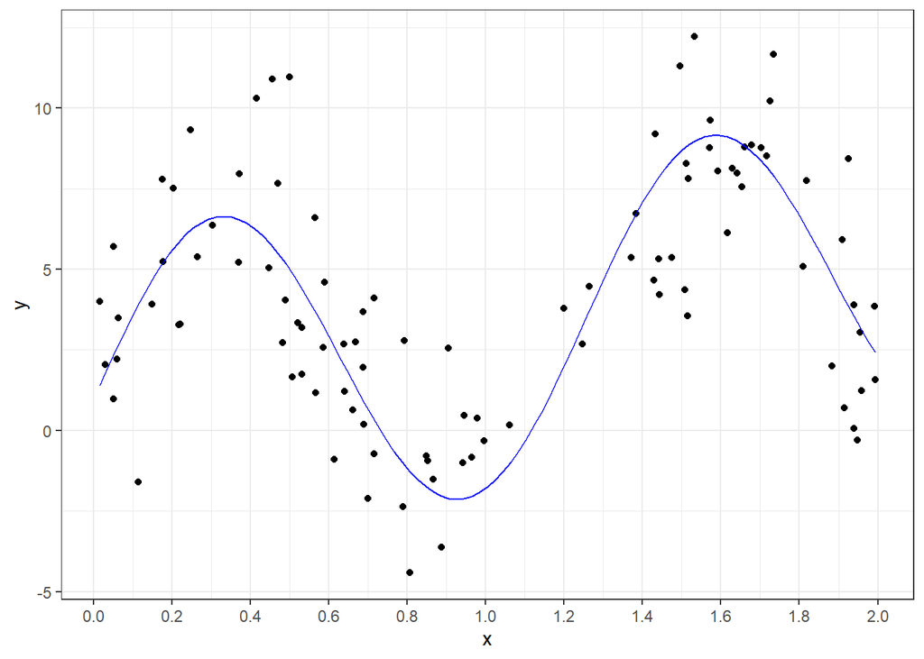

```r
#-- Plot: ggplot
ggplot(data, aes(x,y)) +
  geom_point() +
  geom_function(fun=f, color="blue") +
  scale_x_continuous(breaks=seq(0, 2, by=.20))
```

**Base R**

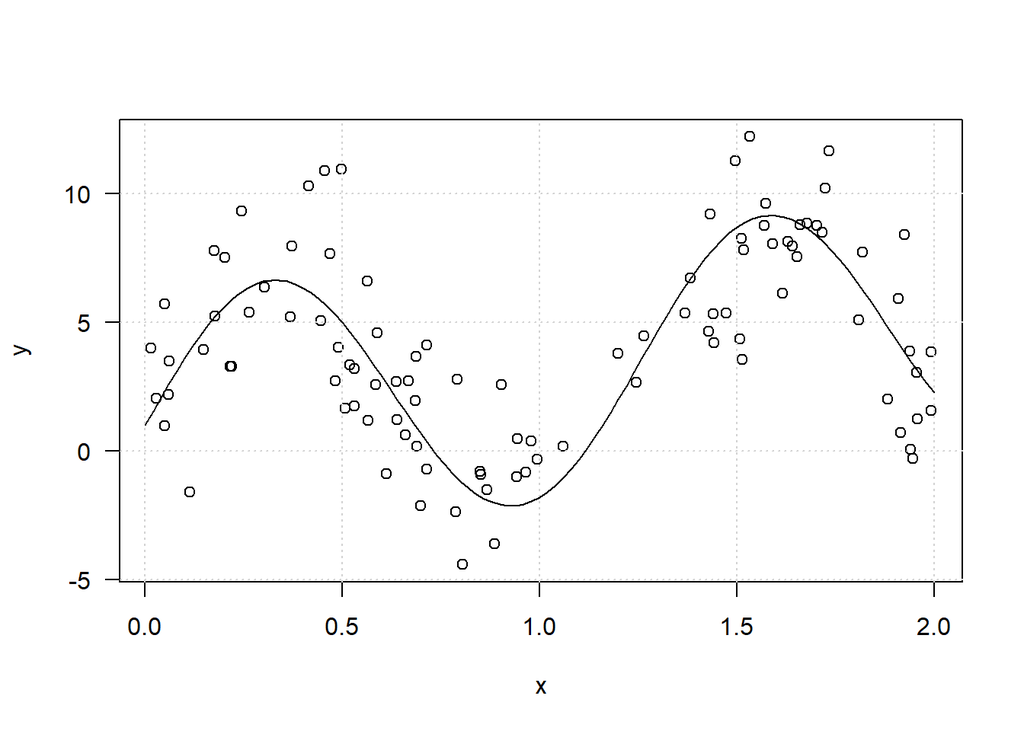

```r
#-- Plot: base R
plot(y~x, data=data, las=1)
grid()
curve(f, from=0, to=2, add=TRUE)
```

## c. 5th degree polynomial fit

Fit a 5th degree polynomial. Produce a scatterplot and draw the *estimated* regression curve.

**Solution**

**Direct**

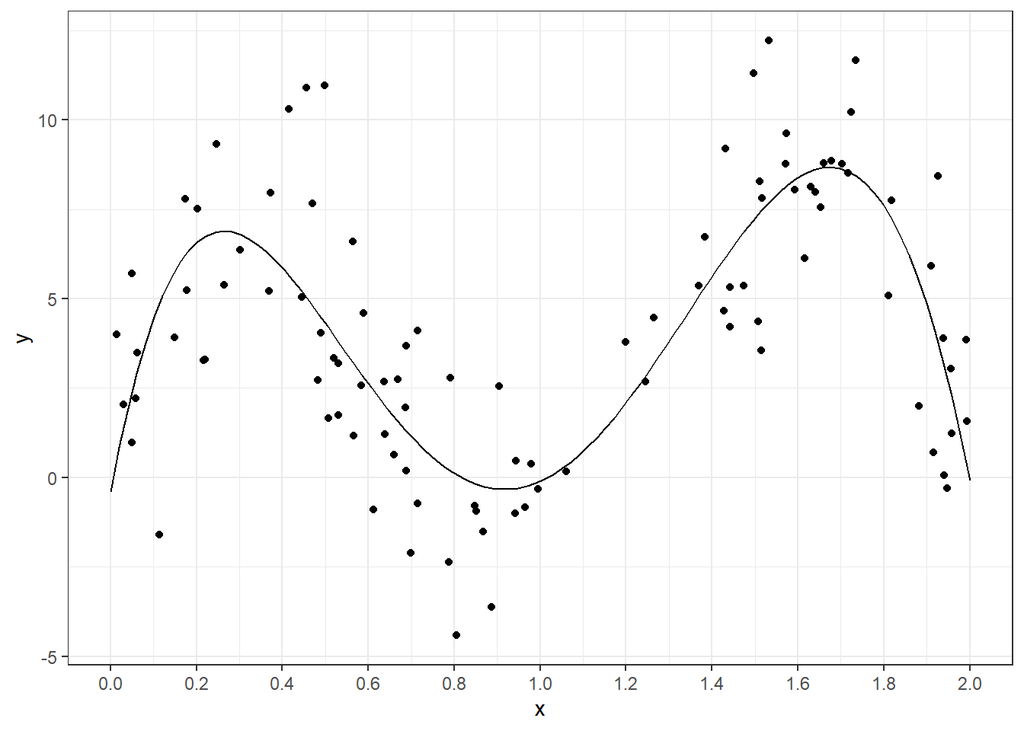

```r
#-- Fit 5th degree polynomial
fit = lm(y~poly(x, degree=5), data=data)

#-- Make predictions
poly_data = tibble(x = seq(0, 2, length=100)) %>% # evaluation points
  mutate(yhat = predict(fit, .))                  # predictions

#-- Plot: ggplot
ggplot(data, aes(x, y)) +
  geom_point() +
  geom_line(data = poly_data, aes(x, yhat)) +
  # geom_function(fun=f, color="blue") + # true mean
  scale_x_continuous(breaks = seq(0, 2, by=.20))
```

**geom_smooth()**

Note: this can be done directly with `geom_smooth()`:

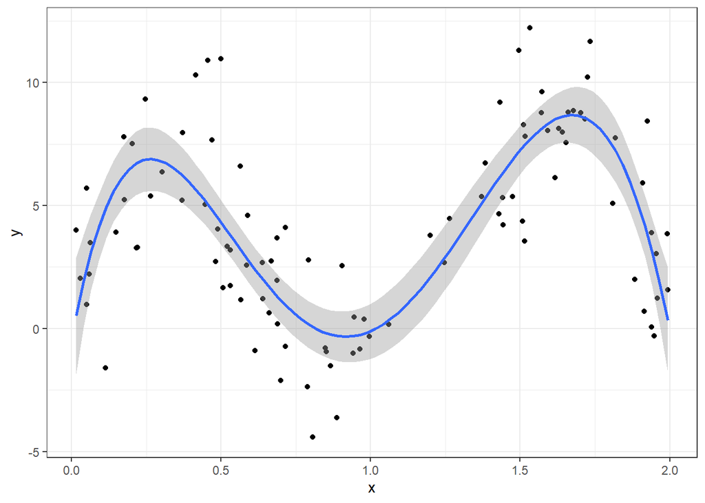

```r
ggplot(data, aes(x, y)) +
  geom_point() +
  geom_smooth(method="lm", formula = "y~poly(x, degree=5)")
```

**tidymodels**

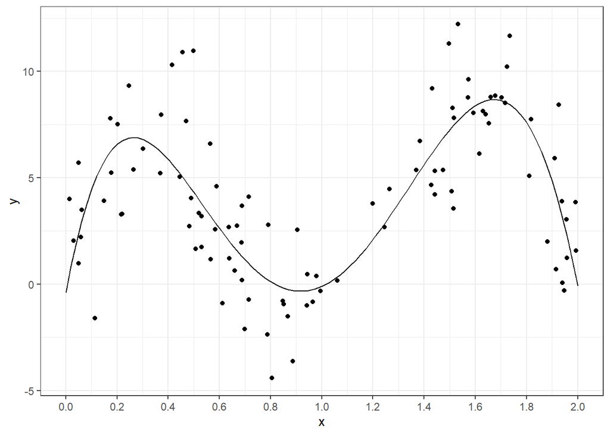

```r
library(tidymodels)
# specify the workflow (combination of preprocessing and model specification)
poly_wf = workflow(
  spec = linear_reg(engine = "lm"),
  preprocessor =
    recipe(
      data = data,
      formula = "y ~ x") %>%
    step_poly(x, degree = 5)
)

# fit the workflow
poly_fit = poly_wf %>% fit(data)

#-- Make predictions
poly_data = tibble(x = seq(0, 2, length=100)) %>% # evaluation points
  mutate(yhat = predict(poly_fit, .)$.pred)       # predictions

#-- Plot: ggplot
ggplot(data, aes(x, y)) +
  geom_point() +
  geom_line(data = poly_data, aes(x, yhat)) +
  # geom_function(fun=f, color="blue") + # true mean
  scale_x_continuous(breaks = seq(0, 2, by=.20))
```

## d. Bootstrap sampling

Make 200 bootstrap samples. For each bootstrap sample, fit a 5th degree polynomial and make predictions at `eval_pts = seq(0, 2, length=100)`

- Set the seed (use `set.seed(212)`) so your results are reproducible.
- Produce a scatterplot with the original data and add the 200 bootstrap curves

**Solution**

```r
eval_pts = seq(0, 2, length=100) # evaluation points
```

Run the bootstrap,

**Using a loop**

```r
#-- Function that returns predictions at eval_pts
fit_poly <- function(data, eval_pts) {
  fit = lm(y ~ poly(x, degree = 5), data=data)
  yhat = predict(fit, tibble(x=eval_pts))
  tibble(x = eval_pts, yhat) # return predictions at eval_pts
}
```

```r
#-- Run bootstrap: with loop
R = 200   # number of bootstrap samples
preds = vector("list", R)
set.seed(212)
for(j in 1:R){
  ind.boot = sample.int(n, replace=TRUE)
  preds[[j]] = fit_poly(data[ind.boot,], eval_pts=eval_pts) %>% mutate(iter = j)
}
boot_data = bind_rows(preds)
```

**Using rsample**

```r
#-- Function that returns predictions at eval_pts
fit_poly <- function(data, eval_pts) {
  fit = lm(y ~ poly(x, degree = 5), data=data)
  yhat = predict(fit, tibble(x=eval_pts))
  tibble(x = eval_pts, yhat) # return predictions at eval_pts
}
```

```r
library(rsample)
set.seed(212)
boots = rsample::bootstraps(data, times = 200)
boot_data = map_df(
  .x = boots$splits,
  .f = ~fit_poly(.x, eval_pts),
  .id = "iter"
)
```

**using the boot() function**

```r
#-- Run bootstrap: using boot::boot() function
fit_poly_boot <- function(data, indices, eval_pts) {
  data.boot = data[indices,]
  fit = lm(y ~ poly(x, degree = 5), data=data.boot)
  predict(fit, tibble(x=eval_pts))  # return predictions at eval_pts
}

set.seed(212)  # Note: boot() resets the seed, so this isn't doing anything
library(boot)
boot.out = boot(data, fit_poly_boot, R=200,
           eval_pts=eval_pts)

preds.boot = t(boot.out$t) # extract fitted curves
```

Plot fitted curves:

**ggplot2**

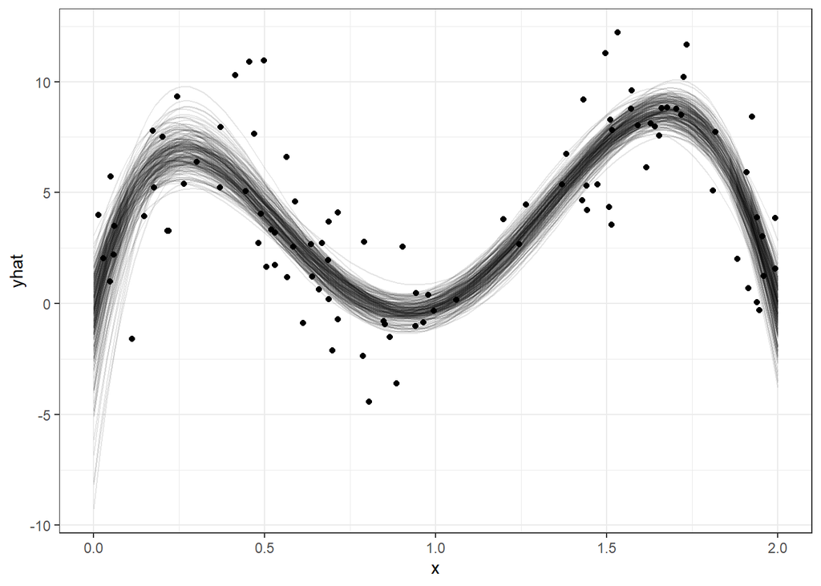

```r
#-- Plots: ggplot2
boot_data %>%
  ggplot(aes(x, yhat)) +
  geom_point(data = data, aes(y=y)) +
  geom_line(aes(group = iter), alpha=.1)
```

**base R**

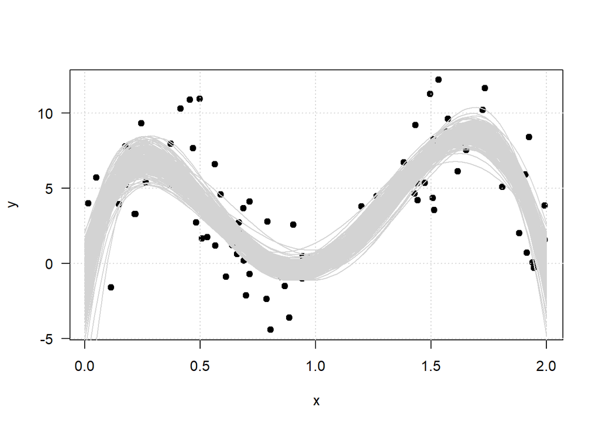

```r
#-- Plots: base R
plot(y~x, data=data, pch=19, las=1)
matlines(eval_pts, preds.boot, type='l', lty=1, col="lightgrey")
grid()
```

## e. Confidence Intervals

Calculate the pointwise 95% confidence intervals from the bootstrap samples. That is, for each $x \in {\rm eval\_pts}$, calculate the upper and lower limits such that only 5% of the curves fall outside the interval at $x$.

- Remake the plot from part *c*, but add the upper and lower boundaries from the 95% confidence intervals.

**Solution**

**Tidyverse**

```r
#-- estimated CI's (data frame method)
CI = boot_data %>%
  group_by(x) %>%
  summarize(
    lower = quantile(yhat, probs=.025),
    upper = quantile(yhat, probs=.975)
  )
```

**Matrix method / apply()**

```r
#-- estimated CI's (matrix method)
CI = t(apply(preds, 1, quantile, probs=c(.025, .975)))
```

**ggplot2**

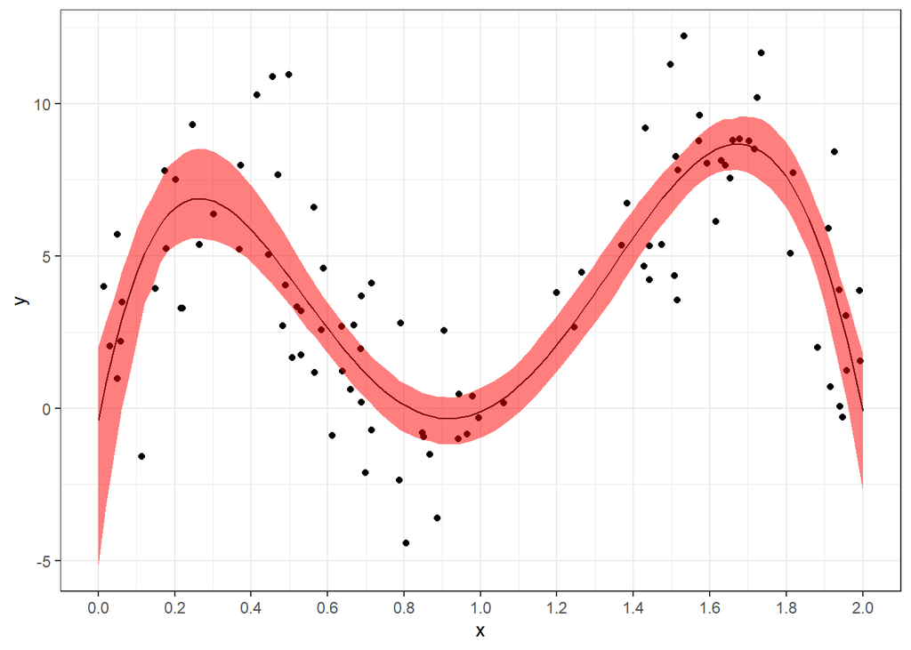

```r
#-- Plot: ggplot2
ggplot(data, aes(x, y)) +
  geom_point() +  # scatterplot
  geom_line(data=poly_data, aes(y=yhat)) +  # original polynomial fit
  geom_ribbon(data = CI, aes(ymin=lower, ymax=upper), fill="red", alpha = .5) +
  #: the above line creates a filled in region for the pointwise CI
  #: alternatively, we could just show the upper and lower two lines
  # geom_line(data=CI, aes(y=lower), color="red", lty=2, size=1.05) +
  # geom_line(data=CI, aes(y=upper), color="red", lty=2, size=1.05) +
  scale_x_continuous(breaks=seq(0, 2, by=.20))
```

**Base R**

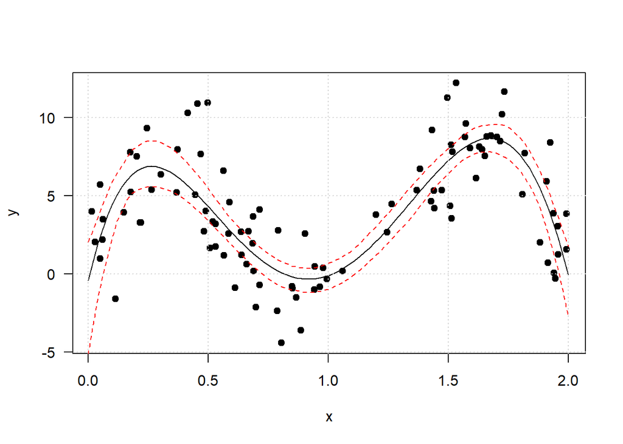

```r
#-- Plots: base R
plot(y~x, data=data, pch=19, las=1)
lines(yhat~x, data=poly_data)
# matlines(eval_pts, preds, type='l', lty=1, col="lightgrey")
grid()
lines(CI$x, CI$lower, col="red", lty=2)
lines(CI$x, CI$upper, col="red", lty=2)
```

# Problem 2: V-Fold cross-validation with $k$ nearest neighbors

Run 10-fold cross-validation on the data generated in part 1b to select the optimal $k$ in a k-nearest neighbor (kNN) model. Then evaluate how well cross-validation performed by evaluating the performance on a large test set. The steps below will guide you.

## a. Implement 10-fold cross-validation

Use $10$-fold cross-validation to find the value of $k$ (i.e., neighborhood size) that provides the smallest cross-validated MSE using a kNN model.

- Search over $k=3,4,\ldots, 40$.
- Use `set.seed(221)` prior to generating the folds to ensure the results are replicable.
- Show the following:
  - the optimal $k$ (as determined by cross-validation)
  - the corresponding estimated MSE
  - produce a plot with $k$ on the x-axis and the estimated MSE on the y-axis (optional: add 1-standard error bars).
- Notation: The $k$ is the tuning paramter for the kNN model. The $v=10$ is the number of folds in V-fold cross-validation. Don’t get yourself confused.

**Solution**

Note: you may get different solutions if you selected the folds differently.

Let’s take this step-by-step

### Step 1: Generate Training Data (from part 1b)

```r
#-- Generate Data
n = 100                                 # number of observations
set.seed(211)                           # set seed for reproducibility
x = sim_x(n)                            # get x values
y = sim_y(x)                            # get y values
data = tibble(x, y)                     # make into tibble
```

### Step 2: Make a function to fit and evaluate a KNN model

```r
#: function to fit and eval knn model
library(FNN)
knn_eval <- function(data_fit, data_eval, K){
  MSE = numeric(length(K))
  for(i in 1:length(K)){
    k = K[i]
    knn = FNN::knn.reg(train = data_fit %>% select(x),
                       y = data_fit$y,
                       test = data_eval %>% select(x),
                       k = k)
    r.val = data_eval$y - knn$pred      # residuals on val data
    MSE[i] = mean(r.val^2)
  }
tibble(k = K, mse = MSE, n_eval = nrow(data_eval))
}
```

### Step 3: Specify cross-validation folds

**Manual**

```r
#- Get K-fold partition
set.seed(221)                      # set seed for replicability
n.folds = 10                       # number of folds for cross-validation
fold = sample(rep(1:n.folds, length=nrow(data)))  # vector of fold labels
# notice how this is different than:  sample(1:K,n,replace=TRUE),
#  which won't give almost equal group sizes
```

**rsample**

```r
library(rsample)
set.seed(221)
cv_data = rsample::vfold_cv(data, v = 10) # 10-fold cross-validation
```

### Step 4: Loop over folds

**Manual Loop**

```r
library(FNN)  # for knn.reg() function
#- Iterate over folds
out = vector("list", n.folds)
for(j in 1:n.folds){

  #: Set training/val data
  val = which(fold == j)
  train = which(fold != j)

  #: fit set of kNN models
  out[[j]] = knn_eval(
    data_fit = data[train,],
    data_eval = data[val,],
    K = 3:40   # set of k values for knn
  ) %>%
    mutate(fold = j)
}
out = bind_rows(out)
```

```
# A tibble: 6 × 4
      k   mse n_eval  fold
  <int> <dbl>  <int> <int>
1     3 10.5      10     1
2     4  7.05     10     1
3     5  7.33     10     1
4     6  6.54     10     1
5     7  6.70     10     1
6     8  6.58     10     1
```

**rsample**

```r
# using purrr::map() family to loop over splits
out = cv_data$splits %>%
  map_df(\(.x) knn_eval(training(.x), testing(.x), K = 3:40),
         .id = "fold")
```

```
# A tibble: 6 × 4
  fold      k   mse n_eval
  <chr> <int> <dbl>  <int>
1 1         3 10.5      10
2 1         4  7.05     10
3 1         5  7.33     10
4 1         6  6.54     10
5 1         7  6.70     10
6 1         8  6.58     10
```

### Step 5: Calculate average performance over all folds

```r
results =
  out %>%
  group_by(k) %>%
    summarize(
      n_folds = n(),
      MSE = mean(mse), # won't be exact if n.val has different counts
      MSE2 = sum(n_eval*mse) / sum(n_eval), # accounts for different sizes
      SE = sd(mse)/sqrt(n)
    ) %>%
  arrange(MSE)
```

```
# A tibble: 6 × 5
      k n_folds   MSE  MSE2    SE
  <int>   <int> <dbl> <dbl> <dbl>
1     8      10  5.94  5.94 0.189
2     9      10  6.03  6.03 0.179
3    11      10  6.09  6.09 0.196
4     6      10  6.14  6.14 0.200
5     7      10  6.18  6.18 0.187
6    10      10  6.21  6.21 0.188
```

### Step 6: Make plot

```r
# Optimal Solution
results %>% slice_min(MSE)
```

```
# A tibble: 1 × 5
      k n_folds   MSE  MSE2    SE
  <int>   <int> <dbl> <dbl> <dbl>
1     8      10  5.94  5.94 0.189
```

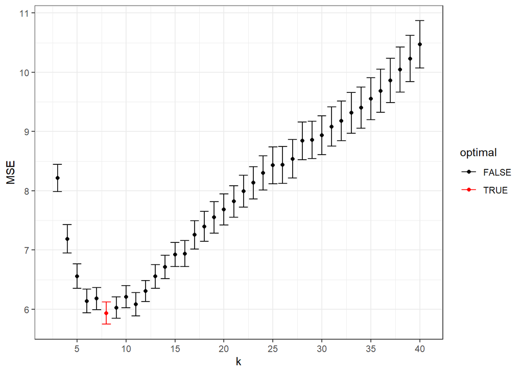

```r
# Plot: ggplot
results %>%
  mutate(optimal = ifelse(MSE == min(MSE), TRUE, FALSE)) %>%
  ggplot(aes(k, color=optimal)) +
  geom_point(aes(y=MSE)) +
  geom_errorbar(aes(ymin=MSE - SE, ymax=MSE+SE)) +
  scale_color_manual(values=c("black", "red")) +
  scale_x_continuous(breaks=seq(0, 50, by=5))
```

### Optional: `tidymodels` solution

Here is an alternative approach fully using the tidymodels framework.

```r
#: Set cross-validation folds
library(rsample)
set.seed(221)
cv_data = rsample::vfold_cv(data, v = 10) # 10-fold cross-validation
```

```r
library(tidymodels)
#: specify the workflow: model and pre-processing
wf_knn = workflow(
  spec = nearest_neighbor(
              neighbors = tune(),            # tuning parameter
              engine = "kknn",
              weight_func = "rectangular",
              mode = "regression",
          ),
  preprocessor = recipe(y~x, data = data)
)

#: run tune_grid() to evaluate performance over grid of tuning parameters
initial_results = tune_grid(
  object = wf_knn,
  resamples = cv_data,
  grid = expand_grid(neighbors = 3:40), # specify grid of tuning parameters
  metrics = metric_set(rmse)
)

#: convert results into convenient format
out = initial_results %>%
  collect_metrics(summarize = FALSE) %>% # summarize=FALSE -> don't aggregate
  transmute(
    fold = id,
    k = neighbors,
    mse = .estimate^2,  # we had RMSE as performance metric; convert to MSE.
    n_eval = 10
  ) %>%
  arrange(fold, k)

#: Aggregate performance over folds
results =
  out %>%
  group_by(k) %>%
    summarize(
      n_folds = n(),
      MSE = mean(mse), # won't be exact if n.val has different counts
      MSE2 = sum(n_eval*mse) / sum(n_eval), # accounts for different sizes
      SE = sd(mse)/sqrt(n)
    ) %>%
  arrange(MSE)
head(results)
```

```
# A tibble: 6 × 5
      k n_folds   MSE  MSE2    SE
  <int>   <int> <dbl> <dbl> <dbl>
1     8      10  5.94  5.94 0.189
2     9      10  6.03  6.03 0.179
3    11      10  6.09  6.09 0.196
4     6      10  6.14  6.14 0.200
5     7      10  6.18  6.18 0.187
6    10      10  6.21  6.21 0.188
```

## b. Find the optimal *edf*

The $k$ (number of neighbors) in a kNN model determines the effective degrees of freedom *edf*. What is the optimal *edf*? Be sure to use the correct sample size when making this calculation. Produce a plot similar to that from part *a*, but use *edf* (effective degrees of freedom) on the x-axis.

**Solution**

In the 10-fold cross-validation, the training sample was $90$ since $n/10 = 10$ observations were held-out for the validation set.

```r
results = results %>% mutate(edf = (nrow(data)*9/10)/k)
results %>% slice_min(MSE)
```

```
# A tibble: 1 × 6
      k n_folds   MSE  MSE2    SE   edf
  <int>   <int> <dbl> <dbl> <dbl> <dbl>
1     8      10  5.94  5.94 0.189  11.2
```

The optimal $k=8$ corresponds to an estimated $edf=11.25$.

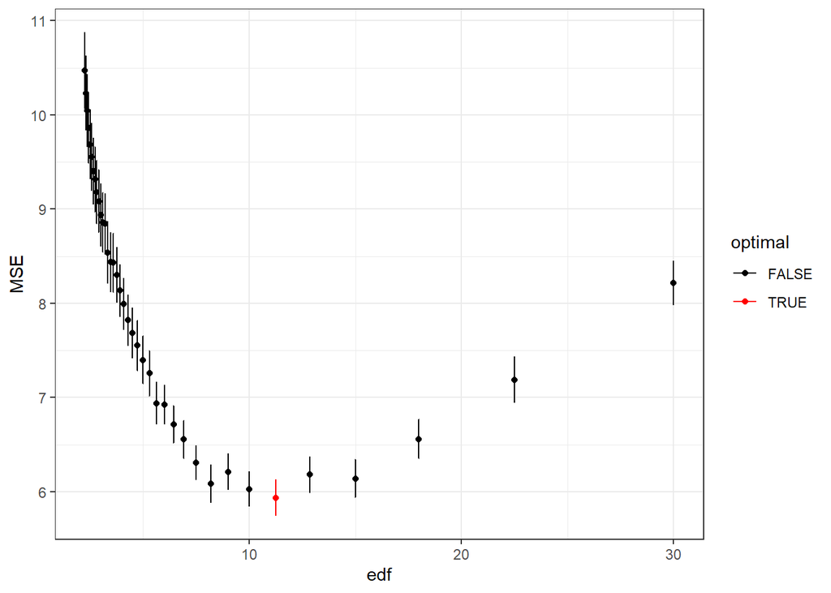

```r
#-- Plot: ggplot
results %>%
  mutate(optimal = ifelse(MSE == min(MSE), TRUE, FALSE)) %>%
  ggplot(aes(edf, color=optimal)) +
  geom_point(aes(y=MSE)) +
  geom_errorbar(aes(ymin=MSE - SE, ymax=MSE+SE)) +
  scale_color_manual(values=c("black", "red"))
```

## c. Choose $k$

After running cross-validation, a final model fit from *all* of the training data needs to be produced to make predictions. What value of $k$ would you choose? Why?

**Solution**

I have given you the freedom to choose your own value, so there are many acceptable answers as along as you provided some justification for your choice.

kNN models are attempting to fit a *local mean* by averaging the responses in a neighborhood of $X$. There is a bias-variance trade-off here; if the neighborhood grows too big there will be high bias, but if $k$ is reduced then the variance increases.

As the size of the training data grows, the distance to the $k$ neighbors will decrease and consequently the bias will be reduced but the variance will stay the same. This implies that the optimal $k$ can potentially be increased (to reduce the variance) with a larger training data.

One way to adjust for this is to use the effective degrees of freedom (*edf*) instead of $k$ to select the final model. Take the optimal *edf* from cross-validation and convert to the optimal $k$ when using the full training data according to $k^* = n/edf^*$:

```r
#-- optimal k on full training set
results %>%
  slice_min(MSE) %>%
  mutate(
    k.full = nrow(data)/edf,
    k.star = round(k.full)  # round() since k must be an integer
  )
```

```
# A tibble: 1 × 8
      k n_folds   MSE  MSE2    SE   edf k.full k.star
  <int>   <int> <dbl> <dbl> <dbl> <dbl>  <dbl>  <dbl>
1     8      10  5.94  5.94 0.189  11.2   8.89      9
```

This suggests that the optimal $k^* = 9$.

Of course this issue is diminished as $n$ and/or $K$ (the number of folds) grows, but it is worthwhile to be aware of (especially if $n$ or $K$ is small).

## d. Evaluate actual performance

Now we will see how well cross-validation performed. Simulate a test data set of $50000$ observations from the same distributions. Use `set.seed(223)` prior to generating the test data.

- Fit a set of kNN models, using the full training data, and calculate the mean squared error (MSE) on the test data for each model. Use the same $k$ values in *a*.
- Report the optimal $k$, the corresponding *edf*, and MSE based on the test set.

**Solution**

Generate the test data:

```r
#-- Generate Test Data
ntest = 50000                           # Number of test samples
set.seed(223)                           # set *different* seed
xtest = sim_x(ntest)                    # generate test X's
ytest = sim_y(xtest)                    # generate test Y's

#-- Data
data_test = tibble(x=xtest, y=ytest)
```

Fit and evaluate the test data:

```r
results_test = knn_eval(data, data_test, K = 3:40) %>%
  mutate(edf = nrow(data) / k)
```

The optimal values are:

```r
results_test %>% slice_min(mse)
```

```
# A tibble: 1 × 4
      k   mse n_eval   edf
  <int> <dbl>  <int> <dbl>
1    13  7.11  50000  7.69
```

## e. Performance plots

Plot both the cross-validation estimated and (true) error calculated from the test data on the same plot. See Figure 5.6 in ISL (pg 182) as a guide.

- Produce two plots: one with $k$ on the x-axis and one with *edf* on the x-axis.
- Each plot should have two lines: one from part *a* and one from part *d*

**Solution**

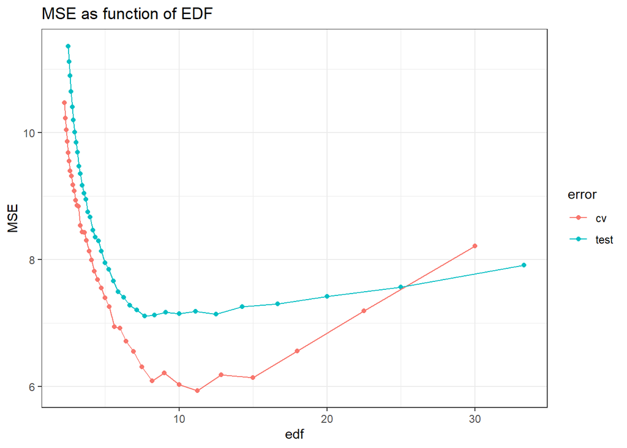

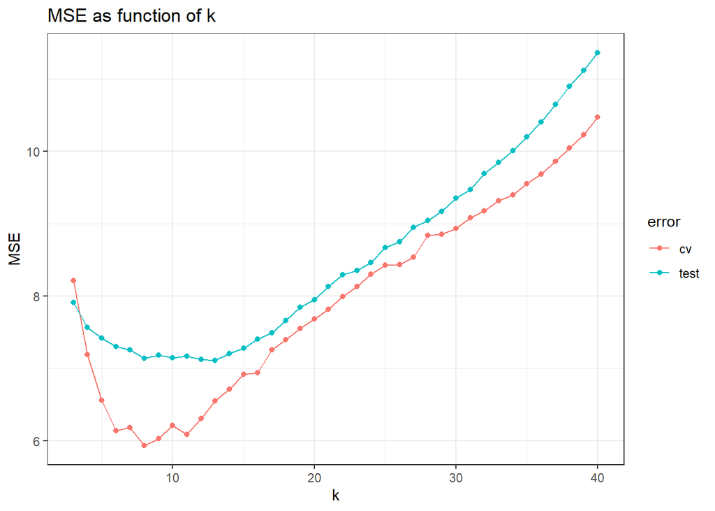

```r
#-- EDF on x-axis
bind_rows(
  cv = results,
  test = results_test %>% rename(MSE = mse),
  .id="error"
  ) %>%
  ggplot(aes(edf, MSE, color=error)) +
  geom_point() + geom_line() +
  labs(title="MSE as function of EDF")

#-- K on x-axis
bind_rows(
  cv = results,
  test = results_test %>% rename(MSE = mse),
  .id="error"
  ) %>%
  ggplot(aes(k, MSE, color=error)) +
  geom_point() + geom_line() +
  labs(title="MSE as function of k")
```

## f. Did cross-validation work as intended?

Based on the plots from *e*, does it appear that cross-validation worked as intended? How sensitive is the choice of $k$ on the resulting test MSE?

**Solution**

In a way, yes cross-validation gives a reasonable structured approach to select the tuning parameter $k$. However it didn’t give the optimal solution; cross-validation suggested a model that was too complex ($k$ too small). Sometimes, this is just the way it works - cross-validation won’t always pick the optimal model. In this case, I suspect part of the problem is the sensitivity of kNN to the very small sample size ($n=100$). And the optimal $k$ will be larger with larger sample sizes.

Another consideration is how flat the test error curve is around the optimal solution. That is, from a visual perspective $k$ values between 5 and 15 appear to give near optimal solutions. of course, the application will guide how close to optimal is necessary for each problem.

Here I’ll plot the percentage error of using a non-optimal $k$

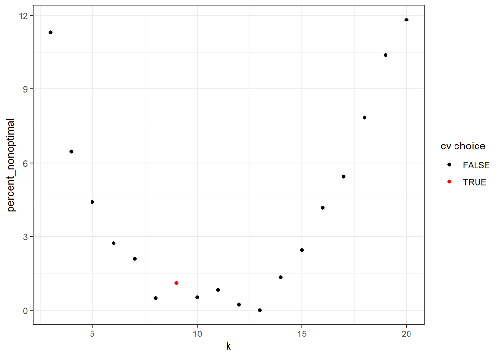

```r
results_test %>%
  mutate(percent_nonoptimal = 100*(mse / min(mse)-1 ),
         optimal = (k == !!k.star)) %>%
  filter(k <= 20) %>%
  ggplot(aes(k, percent_nonoptimal, color=optimal)) +
  geom_point() +
  scale_color_manual(values=c("black", "red"), name = "cv choice")
```

This indicates that although we selected the “wrong” tuning parameter, we still would have had very good performance - almost as good as using the optimal value of $k$.

Because there is so much uncertainty in the cross-validation results, this would’ve been a good time to use repeated cross-validation (or repeated hold-out)!